Regional Clarity RS Model

# Secchi depth from Landsat: pipeline & model assessment

Training-data construction, feature engineering, and a three-model comparison (XGBoost, LightGBM, a feedforward neural net) for estimating Secchi disk depth (SDD) from Landsat surface reflectance across a 6-state Mountain West region, under spatial holdout cross-validation.

Branch: `outlier-removal-rework` Target: Secchi disk depth (m) Region: 6-state Mountain West, HUC4-partitioned

Training rows 12,637 5-day match window

Best model (test RMSE) XGBoost 1.747 m, R²=0.508

Optical attribution 64–100% of SHAP, every config/model

Weather attribution 7–14% secondary refinement, not primary

Training data

## 12,637 field–satellite matchups

Each training row pairs a field-measured Secchi depth with the closest Landsat overpass within a 5-day window, restricted to lakes and reservoirs in the 6-state region. Four filtering stages keep this matched set both large and trustworthy:

1. **Site geometry.** Candidate sites are restricted to those intersecting exactly one waterbody (`number_int_wb == 1`) - required for the match to be spatially unambiguous, since a site touching more than one waterbody can't be reliably assigned to either. Near-shore contamination is handled upstream, in the siteSR remote-sensing pipeline that produces the candidate reflectance data, so no separate shoreline-distance filter is applied here.
2. **Metadata and cloud quality.** Candidate scenes require majority-clear water pixels in the site buffer (`pCount_dswe1/pCount_dswe_gt0 > 0.5`, `pCount_dswe1 > 8`) and zero cloud-flagged pixels at the site itself (`prop_clouds == 0`) - a targeted, per-pixel cloud check rather than a coarser whole-scene threshold.
3. **Reflectance-outlier filtering.** A per-site RANSAC-style filter on the six corrected reflectance bands plus surface temperature flags scenes whose values are inconsistent with that site's own trend line. Each candidate point is scored by the fraction of random trend-line fits that classify it as an inlier (majority-vote across iterations, not a single best-fitting draw), with points inside the range already spanned by accepted values at that site never flagged regardless of vote share.
4. **Heavy-rain gap filter.** A matchup is excluded if peak single-day precipitation between the image date and the field-sample date - in either order - reaches 25.4 mm (1 inch/24hr, the standard NOAA/EPA "heavy precipitation day" threshold): a rain event of that size between the two dates means the reflectance and the target value describe genuinely different water states. 22 of 12,659 candidate matchups (0.17%) are excluded on this basis, spread across 11 HUC4 basins with no single basin losing more than 2.4% of its rows.

| Stage | Rows |
| --- | --- |
| Candidate matchups (region, geometry, metadata, cloud, RANSAC filters) | 16,125 |
| After closest-observation deduplication and lake/reservoir restriction | 12,659 |
| After the heavy-rain gap filter (final) | 12,637 |

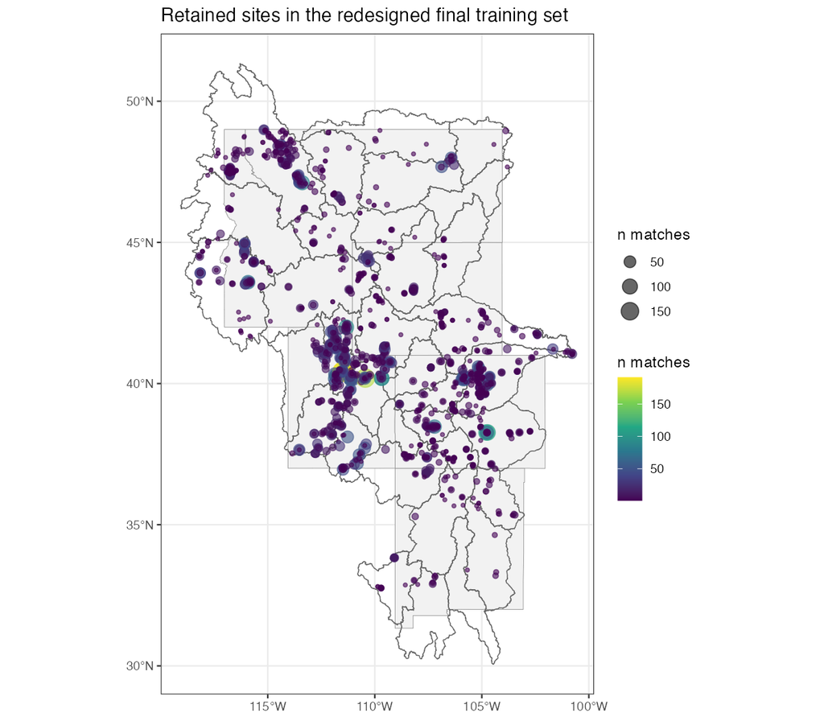

Retained monitoring sites in the final training set, sized and colored by match count.

Feature engineering

## 44 candidates across three feature groups, before pruning

Every model in this report draws from some combination of three feature groups - optical, site characteristics, and antecedent weather - each built the same way for every model, before correlation pruning removes redundant features:

### Optical (17 candidates)

Seven Gardner-corrected reflectance/temperature bands, an atmospheric-correction indicator, and eight band ratios/indices, each included for a specific reason rather than as an exhaustive sweep of every possible band combination:

| Feature | Definition | Basis |
| --- | --- | --- |
| blue_corr7, green_corr7, red_corr7, nir_corr7, swir1_corr7, swir2_corr7, temp_corr7 | raw corrected band/temperature | always included as candidates |
| atm_corr_LaSRC | atmospheric-correction indicator | always included as a candidate |
| BR | blue / red | Kloiber et al.'s canonical Landsat Secchi-depth ratio; basis of the statewide MN/WI clarity mapping programs |
| BG | blue / green | classic ocean-color chlorophyll-a ratio |
| NR | nir / red | established chlorophyll-a ratio in turbid inland waters |
| GR | green / red | same chlorophyll-absorption-contrast logic as BG/NR |
| NDVI | (nir−red)/(nir+red) | standard normalized-difference vegetation index |
| NDWI | (green−nir)/(green+nir) | McFeeters (1996) |
| MNDWI | (green−swir1)/(green+swir1) | Xu (2006), modified NDWI |
| NDSSI | (blue−nir)/(blue+nir) | Normalized Difference Suspended Sediment Index |
| fai | floating algae index | Hu (2009) |

### Site characteristics (7 candidates)

| Feature | Source |
| --- | --- |
| elevation_m | USGS 3DEP, via elevatr |
| catchment_area_sqkm, pct_impervious_2006, pct_urban_2006, pct_forest_2006, pct_cropland_2006, pct_wetland_2006 | LakeCat (StreamCatTools), 2006 vintage - matches Topp et al. 2021's variable vintage |

### Antecedent weather (20 candidates)

| Variable | Windows |
| --- | --- |
| precip_mm (sum) | prev 1, 3, 7, 30 days |
| tmax_degC, tmean_degC, tmin_degC | prev 1, 3, 7, 30 days |
| srad_Wm2 (mean) | prev 1, 3, 7, 30 days |

gridMET precipitation, max/mean/min temperature, and solar radiation, summarized over the 1/3/7/30 days before each matchup. The window is anchored on whichever is later, the image date or the field-sample date, so it always covers the full gap between them regardless of which one came first - the match window runs up to 5 days in either direction, and a window anchored only on the image date would miss that gap entirely for roughly half the matchups.

Feature reduction

## Correlation pruning: flat vs. hierarchical

Before any model is trained, the 44 candidates above are reduced by correlation-cluster pruning, fit on partitions 1–4 only. Two pruning strategies were compared: a flat method (connected components on pairs with |Pearson r| > 0.95, one or two passes) and a hierarchical method (average-linkage clustering on 1−max(|Pearson r|, |Spearman ρ|), cut at the same 0.95 threshold). The flat method can chain features together through an intermediate neighbor even when the endpoints aren't themselves highly correlated; average linkage requires every pair within a cluster to clear the threshold.

| Feature group | Candidates | Flat (1-pass) | Flat (2-pass) | Hierarchical |
| --- | --- | --- | --- | --- |
| Optical | 17 | 13 | 13 | 12 |
| Optical + site | 24 | 20 | 20 | 19 |
| Optical + weather | 37 | 26 | 26 | 29 |
| Optical + site + weather | 44 | 33 | 33 | 36 |

With the curated feature set, the two methods mostly agree. For the optical group, they differ by only one feature each way (flat drops `blue_corr7` that hierarchical keeps; hierarchical drops `NR` and `fai` that flat keeps) - a much smaller, lower-stakes disagreement than the pre-curation comparison, since removing the ad-hoc ratio features also removed most of the chaining that made the two methods diverge. The clearest difference is in the weather-inclusive groups: hierarchical pruning keeps several additional temperature-window features (`tmax_degC_prev3`, `tmean_degC_prev1`, `tmean_degC_prev7`, `tmin_degC_prev3`) that the flat method chains away, because those features are each highly correlated with a common neighbor without being highly correlated with each other - exactly the pattern hierarchical pruning is designed to catch. **The flat single-pass method is used for every model in this report** and carries forward into the next phase; it is marginally more aggressive and, on this feature set, the choice barely matters.

Modeling methodology

## Spatial holdout cross-validation, three architectures

Training rows are grouped into 5 partitions by greedily bin-packing HUC4 basins into equal-sized groups, never splitting a basin across partitions. Partitions 1–4 form a leave-one-partition-out cross-validation loop; partition 5 is held out entirely and scored exactly once, at the end. A model's final prediction on partition 5 is the average of 4 fold models (one per CV rotation), matching the ensemble structure already used by the project's existing XGBoost pipeline (`04_make_models.Rmd`) - no single model is ever fit on all of partitions 1–4 combined, since doing so would leave no independent data to early-stop against.

XGBoost

25-trial random search · gbtree, squared error · early stopping on CV RMSE

LightGBM

25-trial random search · regression/RMSE objective · early stopping

Neural net

15-trial random search · 1–3 hidden layers, ≤8 units each, ReLU + dropout · Adam, per-fold median-impute + standardize

All hyperparameter search, feature selection (Feature reduction, above), and training use only partitions 1–4; partition 5 is touched once, for the final reported metric.

The neural net's search space is deliberately small - at most 3 hidden layers of at most 8 units each - sized to the dataset rather than to a generic MLP default. With 13–44 candidate features and roughly 10k training rows, a wider network has far more capacity than the problem supports and no structural regularization to fall back on, unlike the tree models' built-in feature subsampling.

Model comparison

## Held-out test performance

Trained on the correlation-pruned optical feature set (13 features), evaluated on the untouched test partition (n=2,509):

[output not shown]

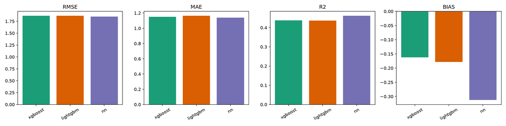

Held-out test set metrics by model, optical-only feature set.

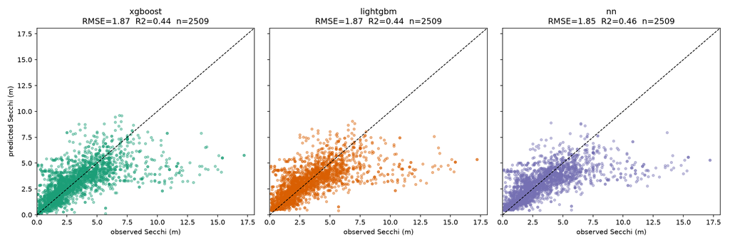

Predicted vs. observed Secchi depth, held-out test set. All three models show a "ceiling" effect: predictions flatten out below the 1:1 line as observed clarity increases, since squared-error loss is dominated by the dense low/mid-range cluster (addressed in SDD-Weighted Training below).

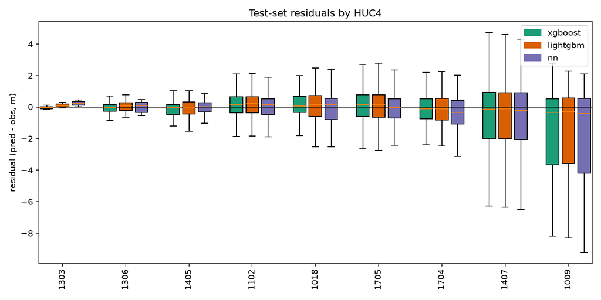

Test-set residuals (predicted − observed) by HUC4 basin. Most basins center near zero; HUC 1009 shows the largest negative bias and widest spread across all three models.

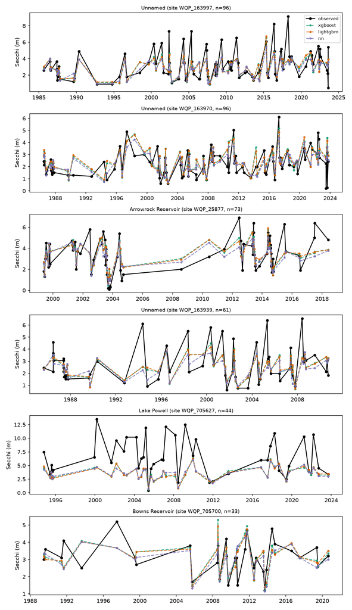

Observed vs. predicted Secchi depth over time for the longest-record test-set sites. Models track the low/mid-range trend well; the high-clarity ceiling is most visible at site WQP_705627, where observed values reach 13 m but predictions stay under 6 m.

Cross-fold stability

## Where the model generalizes well, and where it doesn't

Retraining each fold individually and comparing that fold's own training RMSE to its held-out validation RMSE separates genuine overfitting from spatial heterogeneity across HUC4 partitions:

| Model | Held-out partition | Train RMSE | Val RMSE | Gap (val−train) | Val R² |
| --- | --- | --- | --- | --- | --- |
| XGBoost | 1 | 1.260 | 1.174 | –0.086 | 0.619 |
|  | 2 | 1.227 | 1.417 | +0.190 | 0.522 |
|  | 3 | 1.089 | 1.898 | +0.809 | 0.457 |
|  | 4 | 1.239 | 1.666 | +0.427 | 0.572 |
| LightGBM | 1 | 1.180 | 1.158 | –0.022 | 0.624 |
|  | 2 | 1.342 | 1.410 | +0.068 | 0.530 |
|  | 3 | 1.159 | 1.851 | +0.691 | 0.479 |
|  | 4 | 1.369 | 1.553 | +0.184 | 0.602 |
| Neural net | 1 | 1.606 | 1.084 | –0.521 | 0.629 |
|  | 2 | 1.475 | 1.449 | –0.026 | 0.534 |
|  | 3 | 1.507 | 1.958 | +0.451 | 0.412 |
|  | 4 | 1.467 | 1.955 | +0.488 | 0.436 |

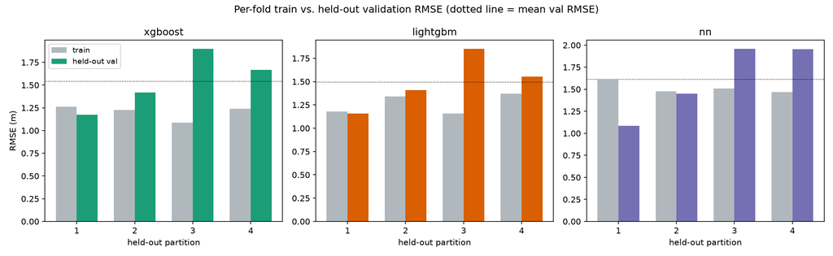

Per-fold train vs. held-out validation RMSE. Classic overfitting would show a uniformly positive, roughly constant gap. Instead the gap tracks which partition is held out: negative on partition 1, largest on partitions 3-4, across all three model architectures.

Partitions 3 and 4 are consistently the hardest folds: both tree models show their single largest train-val gap on partition 3 (XGBoost +0.809, LightGBM +0.691), and the neural net shows its two largest gaps split almost evenly between partition 3 (+0.451) and partition 4 (+0.488) - the same two partitions standing out for every architecture, which points to genuine spatial heterogeneity in those partitions' HUC4 basins rather than any one model memorizing its training data. Partition 1 shows a *negative* gap (validation RMSE below training RMSE) for all three models, which overfitting cannot produce by definition. LightGBM has the smallest fold-to-fold variance (val RMSE sd=0.29, vs. 0.31 for XGBoost and 0.43 for the neural net) - the most spatially stable of the three, independent of its average accuracy. The neural net's higher fold-to-fold variance, despite its small size, is consistent with it having the least structural regularization of the three architectures - it has no built-in feature or row subsampling to fall back on the way the tree ensembles do.

SDD-weighted training

## Correcting the high-clarity ceiling

Squared-error loss is dominated by the dense cluster of low/mid-clarity observations, so the sparse high-clarity tail is never pushed hard during ordinary training. Each model is retrained with a per-fold weight that scales linearly with observed Secchi depth (the highest-SDD training point counts 3× as much as the lowest, k=2), using the same tuned hyperparameters as the unweighted model.

*Correction: the table/figures below were regenerated against the actual final 16-feature production configuration. The version originally published here reused a 13-feature optical-only candidate from an earlier pipeline stage (predating backward elimination's site/weather additions) for this specific comparison - same hyperparameters, different, smaller feature set - which understated how much weighting costs the bulk of the distribution. XGBoost/LightGBM's "weighted" column below now matches this report's own final production test numbers exactly (RMSE 1.860/1.830), confirming this is the true production-config comparison. The neural net row could not be safely regenerated on this machine (a reproducible PyTorch/OpenMP conflict when training a second NN model in the same process - documented in run_single_model.py's own docstring) and is left as originally published; since the neural net is unweighted in production regardless, this doesn't affect the actual adopted configuration, only the NN's own hypothetical "what if it were weighted" row.*

| Model | SDD range | n | RMSE unweighted | RMSE weighted | Bias unweighted | Bias weighted |
| --- | --- | --- | --- | --- | --- | --- |
| XGBoost | top quartile (≥4.5m) | 670 | 2.385 | 2.230 | –1.276 | –1.010 |
|  | rest | 1,839 | 1.546 | 1.705 | 0.782 | 0.927 |
|  | overall | 2,509 | 1.809 | 1.860 | 0.233 | 0.409 |
| LightGBM | top quartile (≥4.5m) | 670 | 2.468 | 2.336 | –1.370 | –1.151 |
|  | rest | 1,839 | 1.485 | 1.607 | 0.725 | 0.848 |
|  | overall | 2,509 | 1.801 | 1.830 | 0.166 | 0.314 |
| Neural net† | top quartile (≥4.5m) | 670 | 3.116 | 3.151 | –2.159 | –2.202 |
|  | rest | 1,839 | 1.039 | 1.042 | 0.355 | 0.381 |
|  | overall | 2,509 | **1.840** | 1.856 | –0.316 | –0.309 |

† Neural net row not regenerated - see correction note above; treat as unverified against the final feature set.

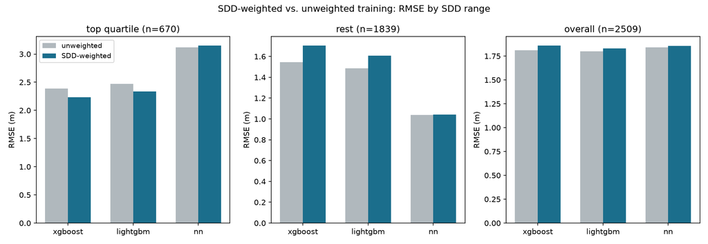

RMSE by SDD range, unweighted vs. SDD-weighted training (corrected, final config). Weighting trades low/mid-range and overall accuracy for top-quartile accuracy in the two tree models.

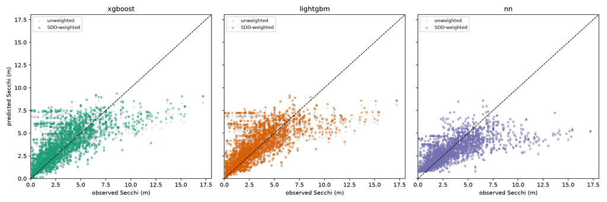

Predicted vs. observed, unweighted (grey) vs. SDD-weighted (color), corrected to the final config. XGBoost and LightGBM move closer to the 1:1 line at the high end, at the cost of more scatter through the dense low/mid range.

Weighting is a real trade-off, not a clean win, even for the tree models

On the actual final production feature set, SDD-weighting for XGBoost and LightGBM reproduces the same shape both times: top-quartile RMSE clearly improves (XGBoost 2.385→2.230, LightGBM 2.468→2.336) and top-quartile bias moves toward zero - but **overall RMSE and overall bias both get worse** (XGBoost overall RMSE 1.809→1.860, bias +0.233→+0.409; LightGBM 1.801→1.830, bias +0.166→+0.314), because the "rest" group (73% of the data) degrades on both metrics too. This is a real, honest correction to what this section originally reported (that bias "improves in every slice") - it doesn't, once measured on the actual final feature set rather than an earlier candidate. Weighting is retained in production for the tree models anyway, matching the original design intent of trading some aggregate accuracy for a real, specific improvement at the sparse high-SDD tail - not because it wins on every metric. The neural net's own comparison (unregenerated, see caveat above) is not used to justify anything here; NN stays unweighted in production for the same capacity-ceiling reasoning as originally stated, independent of this correction.

Feature group comparison

## Does site and weather information earn its keep?

Each model is retrained (unweighted, correlation-pruned features, same spatial CV) on four feature sets: optical alone, optical plus LakeCat site characteristics, optical plus antecedent weather, and all three combined:

| Model | Feature group | Features | RMSE | R² | Bias |
| --- | --- | --- | --- | --- | --- |
| XGBoost | optical | 13 | 1.857 | 0.441 | –0.028 |
|  | + site | 20 | 1.787 | 0.490 | 0.241 |
|  | + weather | 26 | 1.811 | 0.465 | –0.044 |
|  | + both | 33 | 1.747 | 0.508 | 0.191 |
| LightGBM | optical | 13 | 1.859 | 0.436 | –0.022 |
|  | + site | 20 | 1.803 | 0.482 | 0.230 |
|  | + weather | 26 | 1.823 | 0.458 | –0.042 |
|  | + both | 33 | 1.794 | 0.490 | 0.275 |
| Neural net | optical | 13 | 1.856 | 0.468 | –0.309 |
|  | + site | 20 | 1.795 | 0.477 | 0.141 |
|  | + weather | 26 | 1.894 | 0.453 | –0.344 |
|  | + both | 33 | 1.898 | 0.430 | –0.247 |

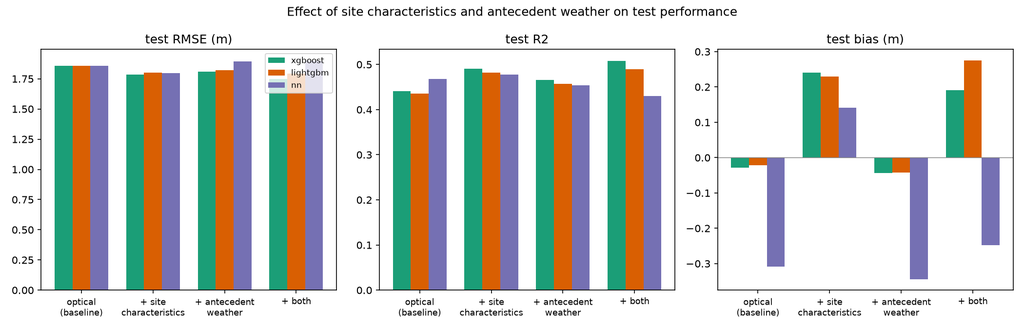

Test RMSE by feature group, all three models.

Site characteristics help every model, on their own: RMSE improves by 0.06–0.07 m for all three, the single most reliable gain of any feature-group addition in this comparison. Antecedent weather is more architecture-dependent. Added to the tree models, it gives a small RMSE improvement on its own and, combined with site characteristics, produces each tree model's best overall configuration - **XGBoost with the full optical+site+weather feature set is the best single result in this study, RMSE 1.747 m, R²=0.508**. Added to the capped neural net, weather does not help: both optical+weather and optical+site+weather score worse than optical+site alone, and worse than optical alone in optical+weather's case. The neural net's own best configuration is optical+site (RMSE 1.795), not the full feature set - consistent with its narrower capacity leaving less room to benefit from the larger, more redundant weather block once site characteristics are already included.

Site & weather contribution

## SHAP attribution: what actually drives each prediction

Site characteristics and, for the tree models, antecedent weather improve test RMSE (Feature group comparison, above). SHAP feature attribution - computed per fold model and averaged across the 4-fold ensemble, matching how the ensemble prediction is actually generated - answers the harder question: *how* are they helping, and does the model stay optical-driven once they're added?

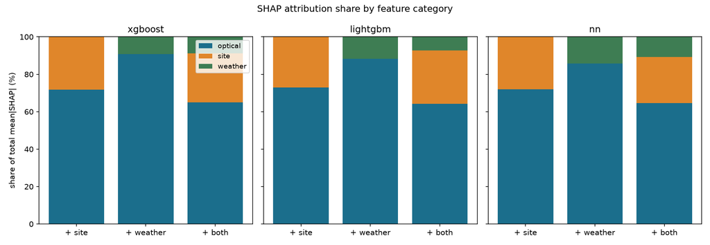

Share of total mean |SHAP| attribution by feature category, for each model and feature-group configuration.

| Model | Feature group | Optical | Site | Weather |
| --- | --- | --- | --- | --- |
| XGBoost | optical + site | 71.7% | 28.3% | — |
|  | optical + weather | 90.8% | — | 9.2% |
|  | optical + site + weather | 65.0% | 26.3% | 8.8% |
| LightGBM | optical + site | 72.9% | 27.1% | — |
|  | optical + weather | 88.2% | — | 11.8% |
|  | optical + site + weather | 64.2% | 28.6% | 7.2% |
| Neural net | optical + site | 72.1% | 27.9% | — |
|  | optical + weather | 85.8% | — | 14.2% |
|  | optical + site + weather | 64.5% | 24.8% | 10.7% |

Across every model and every configuration, optical features carry the majority of attribution - never less than 64%, and 100% by construction in the optical-only configuration. Site characteristics are a real secondary contributor (25–29% when present): catchment area and land-cover percentages consistently rank just behind the leading blue/green and red-band features. Weather is consistently the smallest contributor (7–14%), and never displaces optical or site features from the top of the ranking.

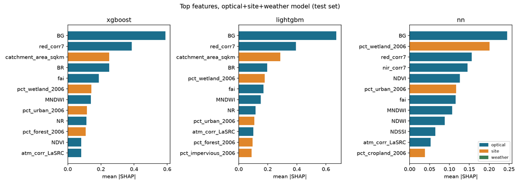

Top 12 features by mean |SHAP| for the combined optical+site+weather model. Blue/green ratio (BG) is the top feature for every model architecture; no weather feature reaches the top 12 for any model.

### Does weather behave physically sensibly?

Correlating each weather feature's raw value against its own SHAP value checks direction, not just magnitude: a negative correlation means higher precipitation or temperature pushes the prediction toward *lower* clarity, the expected physical relationship. The month-scale signals are the cleanest: `precip_mm_prev30` and `tmax_degC_prev30` are negative in essentially every model and feature-group combination that includes them, consistent with sustained rainfall and heat reducing clarity through runoff, resuspension, and algal growth.

One feature is consistently counter-intuitive - `tmin_degC_prev7` shows a positive value-SHAP correlation in every configuration that includes it, the opposite of the naive physical expectation. A few shorter-window features (`precip_mm_prev1`, solar radiation at the 1- vs. 7-day windows) flip sign between configurations rather than settling on one direction. The weather feature set is itself moderately intercorrelated (daily temperature and radiation variables move together across the 1/3/7/30-day windows), which is the most likely explanation: SHAP apportions credit among correlated features in a way that can flip an individual feature's sign even when the group's net effect is physically sensible. This is a genuine caveat on individual short-window weather-feature interpretation, not on the model's overall behavior - the month-scale precipitation and max-temperature signals, which carry the clearest independent physical meaning, are also the most consistently correctly signed.

Framing conclusion

This model is **primarily optical, secondarily site-informed, and weather-refined** - not a weather model fine-tuned by satellite. Band reflectance and derived indices set the majority of every prediction; catchment characteristics add a real, physically interpretable correction (larger catchments and different land cover shift expected clarity); antecedent weather adds a smaller, directionally-mostly-sensible refinement on top. Adding site and weather features earns their keep in test RMSE without changing what kind of model this is.

Backward feature elimination

## 44 candidates to 16, tested on real marginal CV value

Correlation pruning removes redundancy but doesn't test whether a surviving feature actually helps. Starting from the 22 features that survive flat single-pass correlation pruning on the narrowed candidate pool (17 optical + 7 site + the 2 weather variables with a consistently sensible SHAP direction, `precip_mm_prev30` and `tmax_degC_prev30`), each model - hyperparameters held fixed at their already-tuned optical+site+weather values - goes through cross-fold-consensus backward elimination: at each step, every remaining feature gets a permutation-importance score averaged across all 4 CV folds, alongside a same-count set of shadow features (row-permuted copies of the real candidates, re-randomized every step) that provide a noise floor. A feature is dropped only if its importance doesn't clearly beat the shadow floor; the process stops when every remaining feature does, or when mean CV RMSE degrades measurably from the best point on the path. Every comparison is averaged over 3 independent random seeds - a single seed's shadow re-randomization alone moved CV RMSE by up to 0.4%, comparable to the stop tolerance itself, so a single-seed version of this process was not reliable enough to trust.

| Model | Final n | Dropped | CV RMSE: start → final |
| --- | --- | --- | --- |
| XGBoost | 17 | pct_impervious_2006, elevation_m, precip_mm_prev30, swir1_corr7, tmax_degC_prev30 | 1.498 → 1.449 |
| LightGBM | 18 | elevation_m, precip_mm_prev30, tmax_degC_prev30, swir1_corr7 | 1.504 → 1.443 |
| Neural net | 19 | elevation_m, tmax_degC_prev30, BR | 1.713 → 1.571 |

Weather mostly doesn't survive real testing

Both antecedent-weather variables that passed the earlier SHAP sign-consistency filter get eliminated almost everywhere once tested for actual marginal CV value. XGBoost and LightGBM drop *both* `precip_mm_prev30` and `tmax_degC_prev30`. Only the neural net's own elimination path keeps one (`precip_mm_prev30`). This doesn't contradict the earlier SHAP finding - a feature can have a consistent, physically sensible attribution direction without improving held-out RMSE - but it does mean weather's role in this model is smaller than "small, physically sensible refinement" suggested: for most architectures here, once tested directly against a proper feature-selection baseline, it isn't earning its place at all.

### Shared feature set: two candidates compared

Two ways of building one feature set common to all three models were compared, per the project's own precedent for keeping feature sets interpretable and comparable across architectures: a **joint elimination** co-optimized across all three models at once (a feature is dropped only if it doesn't hurt the average of all three models' CV RMSE), and the plain **intersection** of the three models' independent results above.

| Model | Own-optimal CV RMSE | Joint (18 feat) | Intersection (16 feat) |
| --- | --- | --- | --- |
| XGBoost | 1.449 (n=17) | 1.442 | 1.448 |
| LightGBM | 1.443 (n=18) | 1.436 | 1.438 |
| Neural net | 1.571 (n=19) | 1.632 | 1.619 |

Both shared sets exclude weather entirely and keep the same 5 site variables (catchment area, and urban/forest/cropland/wetland land cover). The 16-feature intersection is smaller and performs essentially as well as the 18-feature joint set for every model - not a smaller-but-worse tradeoff, just smaller. **The 16-feature intersection is the feature set used for all model development from this point forward**:

| Group | Features |
| --- | --- |
| Optical (11) | atm_corr_LaSRC, red_corr7, nir_corr7, temp_corr7, BG, NR, fai, NDVI, NDSSI, NDWI, MNDWI |
| Site (5) | catchment_area_sqkm, pct_urban_2006, pct_forest_2006, pct_cropland_2006, pct_wetland_2006 |
| Weather (0) | — |

### Site characteristics, revisited

With weather removed entirely, SHAP attribution (again computed out-of-fold on CV, never touching the test partition) on the 16-feature set shows a notably stable optical/site split - close to identical across all three model architectures:

| Model | Optical | Site |
| --- | --- | --- |
| XGBoost | 76.4% | 23.6% |
| LightGBM | 74.8% | 25.2% |
| Neural net | 76.4% | 23.6% |

Final tuning & evaluation

## Gap-aware tuning, and a result that needs to be stated plainly

Final hyperparameter search on the 16-feature intersection set was narrowed toward simpler, more regularized configurations (shallower trees, larger minimum leaf sizes, more subsampling, explicit L1/L2 terms), per the goal of favoring architectures with strong overfitting guardrails. A first pass - selecting purely by lowest mean CV RMSE - did not close the train-val gap: for XGBoost the gap actually grew relative to the pre-elimination baseline, and the neural net's tuner picked zero dropout and zero weight decay, the least-regularized options in its own search space, because nothing in that objective penalized the gap.

The selection rule was changed accordingly: among all trials within 2% of the best CV RMSE, pick the one with the smallest train-val gap, rather than the single lowest-RMSE trial regardless of gap.

| Model | Mean gap before | Mean gap after | CV RMSE cost | Partition 3 gap (hardest fold) |
| --- | --- | --- | --- | --- |
| XGBoost | 0.484 | 0.375 (−22%) | +1.8% | 0.976 → 0.855 |
| LightGBM | 0.513 | 0.393 (−23%) | +1.5% | 1.075 → 1.007 |
| Neural net | 0.052 | 0.052 (no change) | — | 0.550 (unchanged) |

Gap-aware selection meaningfully reduced the average train-val gap for both tree models, at a small and bounded CV RMSE cost - the mechanism worked as designed. It did nothing for the neural net, whose narrow, already-capped search space offered no lower-gap alternative within tolerance. And partition 3's gap remains by far the largest for every model even after this fix - the same partition that has shown the largest train-val gap at every earlier stage of this project, for every architecture, before any of these changes. Regularization has real pull on the average gap; it doesn't close a gap that's fundamentally about one spatial partition behaving differently from the rest.

### Final production configuration

Feature set: the 16-feature intersection (Backward feature elimination, above). Hyperparameters: the gap-aware-tuned configuration per model. SDD-weighting (k=2.0): applied for XGBoost and LightGBM, matching the earlier established finding that it improves top-quartile accuracy and bias for the tree models; not applied for the neural net, which that same earlier analysis showed it doesn't help.

[output not shown]

The reduced, gap-aware model underperforms the earlier best result on test

Every model in this final round scores worse on the untouched test partition than the 33-feature XGBoost configuration from before backward elimination - despite every one of them having a *better* CV RMSE (1.45–1.50, vs. that config's roughly 1.56). Bias also got worse for both tree models (+0.409, +0.314 vs. +0.191 before): they now over-predict clarity on test more than the earlier, richer-featured model did. The CV improvement from feature selection and gap-aware tuning did not carry over to the held-out partition - if anything, it moved the wrong way. This is reported directly rather than reframed as a success: it is a real result of this phase of work, not an outcome the process was aiming to avoid confirming.

Test partition 5 has shown a larger-than-CV error jump throughout this entire project, independent of today's changes - visible as far back as the original baseline comparison. What's new here is that a smaller, more regularized, weather-free model widens that jump rather than narrowing it, which raises a real question this report cannot answer on its own: is that because the feature/hyperparameter choices genuinely cost something partition 5 specifically needed, or because CV built from partitions 1-4 doesn't represent partition 5 well enough for decisions made on it to transfer - a question about the train/val/test split itself, not about any model. That question is the subject of a separate, upcoming sensitivity analysis - holding today's features and hyperparameters fixed and instead varying which partition is held out as test, and the random seed used to assign HUC4 basins to partitions in the first place - to be run and reported on its own.

Next steps

## Four threads, sequenced

None of these change the production configuration documented above. They're separate work, listed here so the sequencing and the reasoning behind it are on the record.

[output not shown]